# 第二题：决策树处理回归任务

实验内容

1. 使用sklearn.tree.DecisionTreeRegressor完成kaggle房价预测问题
2. 计算最大深度为10的决策树，训练集上十折交叉验证的MAE和RMSE
3. 绘制最大深度从1到30，决策树在训练集和测试集上MAE的变化曲线
4. 选择一个合理的树的最大深度，并给出理由

## 1. 读取数据

```python
import pandas as pd
data = pd.read_csv('data/kaggle_house_price_prediction/kaggle_hourse_price_train.csv')
```

```python
# 丢弃有缺失值的特征（列）
data.dropna(axis = 1, inplace = True)

# 只保留整数的特征
data = data[[col for col in data.dtypes.index if data.dtypes[col] == 'int64']]
```

```python
data.head()
```

|  | Id | MSSubClass | LotArea | OverallQual | OverallCond | YearBuilt | YearRemodAdd | BsmtFinSF1 | BsmtFinSF2 | BsmtUnfSF | ... | WoodDeckSF | OpenPorchSF | EnclosedPorch | 3SsnPorch | ScreenPorch | PoolArea | MiscVal | MoSold | YrSold | SalePrice |
| --- | --- | --- | --- | --- | --- | --- | --- | --- | --- | --- | --- | --- | --- | --- | --- | --- | --- | --- | --- | --- | --- |
| 0 | 1 | 60 | 8450 | 7 | 5 | 2003 | 2003 | 706 | 0 | 150 | ... | 0 | 61 | 0 | 0 | 0 | 0 | 0 | 2 | 2008 | 208500 |
| 1 | 2 | 20 | 9600 | 6 | 8 | 1976 | 1976 | 978 | 0 | 284 | ... | 298 | 0 | 0 | 0 | 0 | 0 | 0 | 5 | 2007 | 181500 |
| 2 | 3 | 60 | 11250 | 7 | 5 | 2001 | 2002 | 486 | 0 | 434 | ... | 0 | 42 | 0 | 0 | 0 | 0 | 0 | 9 | 2008 | 223500 |
| 3 | 4 | 70 | 9550 | 7 | 5 | 1915 | 1970 | 216 | 0 | 540 | ... | 0 | 35 | 272 | 0 | 0 | 0 | 0 | 2 | 2006 | 140000 |
| 4 | 5 | 60 | 14260 | 8 | 5 | 2000 | 2000 | 655 | 0 | 490 | ... | 192 | 84 | 0 | 0 | 0 | 0 | 0 | 12 | 2008 | 250000 |

5 rows × 35 columns

## 2. 数据集划分

70%做训练集，30%做测试集

```python
from sklearn.utils import shuffle
```

```python
data_shuffled = shuffle(data, random_state = 32)
split_line = int(len(data_shuffled) * 0.7)
training_data = data_shuffled[:split_line]
testing_data = data_shuffled[split_line:]
```

## 3. 导入模型

```python
from sklearn.model_selection import cross_val_predict
from sklearn.metrics import mean_absolute_error
from sklearn.metrics import mean_squared_error
```

```python
from sklearn.tree import DecisionTreeRegressor
```

## 4. 选取特征和标记

```python
features = data.columns.tolist()
target = 'SalePrice'
features.remove(target)
```

## 5. 训练与预测

请你在下面计算树的最大深度为10时，使用训练集全量特征训练的决策树的十折交叉验证的MAE和RMSE

```python
# YOUR CODE HERE
model = DecisionTreeRegressor(max_depth=10)

prediction = cross_val_predict(model, training_data[features], training_data[target], cv = 10)

mae = mean_absolute_error(training_data[target], prediction)
rmse = mean_squared_error(training_data[target], prediction) ** 0.5

print('MAE\t\t\tRMSE')
print(str(mae) + '\t' + str(rmse))
```

```
MAE			RMSE
26615.123271753007	41573.844502425585
```

最大深度为10，全量特征的决策树，十折交叉验证指标

| MAE | RMSE |
| --- | --- |
| 26615.123271753007 | 41573.844502425585 |

## 6. 改变最大深度，绘制决策树的精度变换图

绘制最大深度从1到30，决策树训练集和测试集MAE的变化图，要把两个曲线画在一张图内，横坐标是最大深度，纵坐标是MAE

```python
import matplotlib
import matplotlib.pyplot as plt
%matplotlib inline
plt.style.use("fivethirtyeight")
matplotlib.rcParams['font.family'] = 'SimHei'
```

```python
# YOUR CODE HERE
train_mae = []
test_mae = []
for i in range(1, 31):
    model = DecisionTreeRegressor(max_depth = i)
    pred1 = cross_val_predict(model, training_data[features], training_data[target], cv = 10)
    pred2 = cross_val_predict(model, testing_data[features], testing_data[target], cv = 10)
    train_mae.append(mean_absolute_error(training_data[target], pred1))
    test_mae.append(mean_absolute_error(testing_data[target], pred2))

df = pd.DataFrame({'训练集MAE':train_mae, '预测集MAE': test_mae})

row_index = []
for i in range(1, 31):
    row_index.append(i)

df.index = row_index
df.head(df.shape[0])
```

|  | 训练集MAE | 预测集MAE |
| --- | --- | --- |
| 1 | 44077.787408 | 41716.183748 |
| 2 | 34775.418844 | 35567.574833 |
| 3 | 30740.745955 | 32304.599995 |
| 4 | 29202.742208 | 30218.427436 |
| 5 | 28765.368999 | 28415.466984 |
| 6 | 27744.685692 | 27013.885120 |
| 7 | 27184.805419 | 26534.461396 |
| 8 | 27020.211247 | 27357.941496 |
| 9 | 27236.224997 | 26556.555218 |
| 10 | 27624.798011 | 28481.513964 |
| 11 | 27123.956167 | 27669.870907 |
| 12 | 27434.030361 | 26310.193049 |
| 13 | 27869.717191 | 27603.308150 |
| 14 | 28126.516793 | 26667.247597 |
| 15 | 28015.679473 | 27322.602097 |
| 16 | 27884.127104 | 26984.730696 |
| 17 | 27685.709989 | 27628.264996 |
| 18 | 28968.242049 | 27828.513830 |
| 19 | 27620.485092 | 27887.760820 |
| 20 | 28419.600366 | 27100.779043 |
| 21 | 27753.160953 | 26869.475323 |
| 22 | 27239.725759 | 28298.430524 |
| 23 | 27615.771792 | 27717.230068 |
| 24 | 27289.227228 | 27232.963554 |
| 25 | 27696.768854 | 26626.109339 |
| 26 | 27754.529873 | 26478.164009 |
| 27 | 27083.444662 | 27171.154897 |
| 28 | 27743.394711 | 27076.943052 |
| 29 | 27229.541626 | 27400.981777 |
| 30 | 28282.298727 | 27280.391800 |

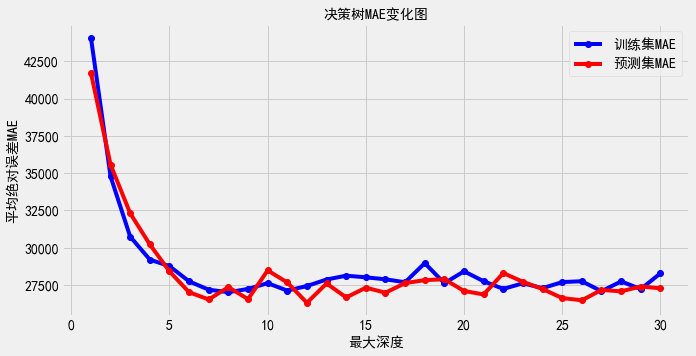

```python
x = list(range(1, 31))

plt.figure(figsize=(10, 5))
plt.xlabel('最大深度', fontproperties='SimHei')
plt.ylabel('平均绝对误差MAE', fontproperties='SimHei')
# plt.xticks(np.linspace(0, 30, 31))
plt.title('决策树MAE变化图', fontproperties='SimHei')

# for i in range(len(x)):
#     plt.text(x[i], df['训练集MAE'][i], "{:.2f}".format(df['训练集MAE'][i]), family='monospace', verticalalignment='bottom',
#              horizontalalignment='right', color='b', fontsize=13)
#     plt.text(x[i], df['预测集MAE'][i], "{:.2f}".format(df['预测集MAE'][i]), family='monospace', verticalalignment='bottom',
#              horizontalalignment='right', color='r', fontsize=13)

plt.plot(x, df['训练集MAE'], 'o-', color='b', label='训练集MAE')
plt.plot(x, df['预测集MAE'], 'o-', color='r', label = '预测集MAE')

plt.legend()

plt.show()
```

请你选择一个合理的树的最大深度，并给出理由

答: 由图可知, 当最大深度大于7时, MAE的趋势变化变得平缓, 因此再去增大深度对模型预测结果不会有太大帮助, 因此我认为最大深度为7